# Homework 2

Author

Megan Liu

Published

May 26, 2026

## Before your start the assignment

- Update the header - put your name in the `author` argument and put today’s date in the `date` argument.
- Click the “Render” button in RStudio and then open the rendered `2-hw2.html` page.
- Then go back and try changing the `theme` argument in the header to something else - you can see other available themes [here](https://quarto.org/docs/output-formats/html-themes.html). Notice the difference when you render now!

## Overview of HW2

Create a data visualization that helps answer the question:

> **How have the number and cost of billion-dollar disasters in the US changed over time?**

You will use the NOAA Billion-Dollar Disaster dataset to explore how visual encoding choices (e.g., color, position, length) help communicate trends clearly and effectively.

**Skills practiced**:

- Downloading and importing real-world data from a public source (NOAA)
- Wrangle and explore a real-world dataset using tidyverse
- Identify appropriate visual encodings based on variable types and goals
- Create a clear and effective time-series visualization with ggplot2
- Apply design principles (titles, colors, themes, alt text) for accessibility and clarity

### Load Required Packages

```r
library(tidyverse)
library(janitor)
# load other packages as you see fit but remember to add comments to explain what each package does
```

## Q1: Prepare the data

Following these steps to download and read in the dataset:

1. Download the dataset from [NOAA](https://www.ncei.noaa.gov/access/metadata/landing-page/bin/iso?id=gov.noaa.nodc:0209268). Under “Access” tab, choose the HTTPS option to download the data. Scroll to the bottom of the list to download the **most recent published version**. Read more about the dataset [here](https://www.ncei.noaa.gov/access/billions/).
2. Place the downloaded CSV file `events-US-1980-2024-Q4.csv` into your `data/` folder in your HW repository. You will notice there is a graph that comes with the data, we will circle back to it later.
3. Add your data/ folder to .gitignore to avoid pushing data to GitHub.
4. Read in the CSV file using `read_csv()`

```r
# remove the eval=FALSE when you render quarto document
df_disasters <- read_csv("/Users/meganliu/Documents/MPH/Summer 2026/PH 6199/Homeworks/Homework 2/2026-hw2-meganyliu/data:/events-US-1980-2024-Q4.csv", skip = 2) |>
  janitor::clean_names()
# the skip argument is used to skip the first two rows of the CSV file, which contain metadata about the dataset.
```

5. Skim through the dataset to get familiar with the variable names, especially:
- `disaster`: the type of disaster (e.g., flood, drought, etc.)
- `begin_date`: the date when the disaster began
- `end_date`: the date when the disaster ended
- `cpi_adjusted_cost`: the total damages caused by the disaster (in billions of dollars)
- `deaths`: the number of deaths caused by the disaster
6. Create a new column `year` that extracts the year from the `begin_date` column. You can use the `lubridate` package to do this.

```r
# remove the eval=FALSE when you render quarto document
df_disasters <- df_disasters |>
  mutate(year = lubridate::year(ymd(begin_date)))
```

7. Explore the dataset and answer these questions:
- Are there any missing or zero values in the cost or deaths columns? How might they affect your visualizations?
- What are the top 5 most common disaster types?
- Calculate the total CPI-adjusted cost of disasters per year. Identify the top 3 most expensive years.

```r
glimpse(df_disasters)
```

```
#> Rows: 403
#> Columns: 8
#> $ name              <chr> "Southern Severe Storms and Flooding (April 1980)", …
#> $ disaster          <chr> "Flooding", "Tropical Cyclone", "Drought", "Freeze",…
#> $ begin_date        <dbl> 19800410, 19800807, 19800601, 19810112, 19810505, 19…
#> $ end_date          <dbl> 19800417, 19800811, 19801130, 19810114, 19810510, 19…
#> $ cpi_adjusted_cost <dbl> 2749.4, 2236.2, 40681.2, 2076.4, 1409.1, 2217.8, 160…
#> $ unadjusted_cost   <dbl> 706.8, 590.0, 10020.0, 572.0, 401.4, 662.0, 483.2, 4…
#> $ deaths            <dbl> 7, 13, 1260, 0, 20, 85, 33, 30, 45, 50, 21, 0, 14, 1…
#> $ year              <dbl> 1980, 1980, 1980, 1981, 1981, 1982, 1982, 1982, 1982…
```

```r
summary(df_disasters)
```

```
#>      name             disaster           begin_date          end_date
#>  Length:403         Length:403         Min.   :19800410   Min.   :19800417
#>  Class :character   Class :character   1st Qu.:20020851   1st Qu.:20021019
#>  Mode  :character   Mode  :character   Median :20130910   Median :20131117
#>                                        Mean   :20100849   Mean   :20101028
#>                                        3rd Qu.:20200763   3rd Qu.:20200807
#>                                        Max.   :20241009   Max.   :20241231
#>  cpi_adjusted_cost unadjusted_cost      deaths             year
#>  Min.   :  1064    Min.   :   400   Min.   :   0.00   Min.   :1980
#>  1st Qu.:  1627    1st Qu.:  1105   1st Qu.:   0.50   1st Qu.:2002
#>  Median :  2457    Median :  1738   Median :   5.00   Median :2013
#>  Mean   :  7238    Mean   :  5112   Mean   :  41.98   Mean   :2010
#>  3rd Qu.:  4923    3rd Qu.:  3236   3rd Qu.:  25.00   3rd Qu.:2020
#>  Max.   :201298    Max.   :125030   Max.   :2981.00   Max.   :2024
```

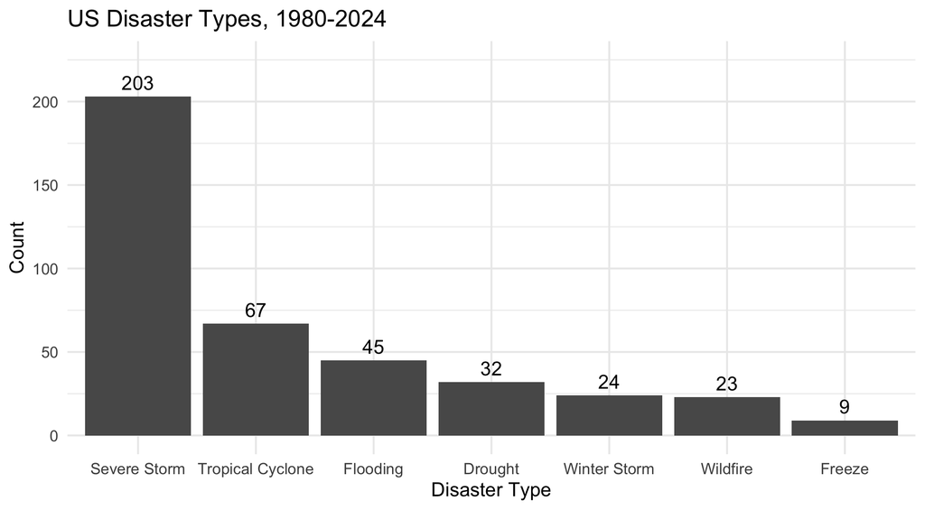

```r
df_disasters %>%
  group_by(disaster) %>%
  summarise(count = n()) %>% # summarize the number of disasters
  ggplot(aes(x = fct_reorder(disaster, -count), y = count)) + # reorder in descending order for easy visualization
  geom_col() + # Create bar graph using geom_col()
  geom_text(aes(label = count, vjust = -0.5)) +
  scale_y_continuous(limits = c(0, 225)) + # increase y-axis limits so that bar count labels are visible
  labs(title = "US Disaster Types, 1980-2024", x = "Disaster Type", y = "Count") +
  theme_minimal()
```

```r
df_disasters %>% # find most expensive disasters by year, by grouping by year
  group_by(year) %>%
  summarize(total_cpicost = sum(cpi_adjusted_cost, na.rm = TRUE)) %>% # then add up costs by year
  arrange(desc(total_cpicost)) # and display in descending order to answer the question
```

```
#> # A tibble: 44 × 2
#>     year total_cpicost
#>    <dbl>         <dbl>
#>  1  2017       395936.
#>  2  2005       268593.
#>  3  2022       188353.
#>  4  2024       182714.
#>  5  2021       164299.
#>  6  2012       158736.
#>  7  2020       120585.
#>  8  2018       116034.
#>  9  2011        97936.
#> 10  2008        93956.
#> # ℹ 34 more rows
```

```r
sum(df_disasters$cpi_adjusted_cost) # Checked the total sum of costs; above says the unit is billions of dollars, but total comes out to 2916862, so should be in millions as $2,916,862 million would equate to $2.9 trillion, which is how much the NOAA dataset overview webpage states that the disaster costs amounted to between 1980 to 2024.
```

```
#> [1] 2916862
```

**NoteYour Answer**

- Missing data: There doesn’t appear to be missing values, but there are zero values in the cost or deaths columns. This may result in making it look like some disasters didn’t result in any costs or deaths, even though this most likely means that data wasn’t available or collected. This may result in data visualizations (e.g. a line graph) where year is on the x-axis and deaths or costs on the y-axis having trends close to 0, making it hard to understand the true relationship between disaster types and outcomes like deaths or disaster costs; or, having more variation in the data/trend than one may expect.
- 5 most disaster types: The 5 most common disaster types were (1) Severe Storm, which occurred 203 times between 1980 to 2024; (2) Tropical Cyclone, which occurred 67 times between 1980 to 2024; (3) Flooding, which occurred 45 times; (4) Drought, which occurred 32 times; and (5) Winter Storm, which occurred 24 times.
- 3 most expensive years by CPI-adjusted cost: The 3 most expensive years by CPI-adjusted cost were (1) 2017, at $395,936.20 million; (2) 2005, at $268,593.30 million; and (3) 2022, at $188,352.90 million.

## Q2: Build your visualization

Create a data visualization that summarizes trends over time (year or decade) in the frequency and/or cost of disasters.

Your final visualization should:

- Use data from 1980 to 2024 only
- Include a title (short, descriptive), subtitle (main takeaway), caption (e.g., “Data: NOAA Billion-Dollar Disasters (accessed 2025)”)
- Apply strategies for highlighting patterns or trends (e.g., highlighting recent years, distinguishing types of disasters)
- Use custom colors rather than ggplot defaults
- Use a clean, polished theme
- Include at least one theme adjustments (e.g., axis labels, legend position, font size) to improve readability/visual appeal

```r
# Goal is to present a table that shows trends in annual disaster costs per year in billions of dollars. To do so, will need to summarize total cpi_adjusted_cost by year, and adjust the cpi_adjusted_cost column to show values in billions, not millions (as it currently is).

df_disasters2 <- df_disasters %>% # Create new dataframe in order to graph annual disaster costs
  select(disaster, year, cpi_adjusted_cost) %>% # Select for the 3 relevant columns
  mutate(cpi_adjusted_cost_mil = (cpi_adjusted_cost/1000)) # Add new column where cost unit updated to billions

sum(df_disasters2$cpi_adjusted_cost_mil) # Check that values add up to $2.9 trillion
```

```
#> [1] 2916.862
```

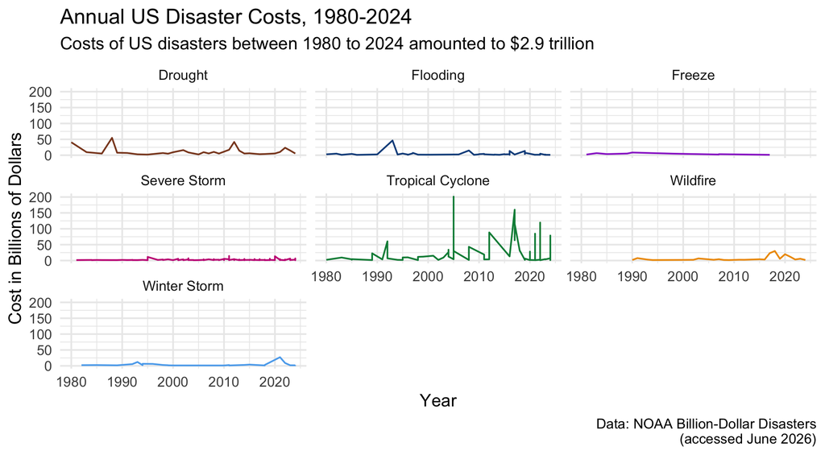

```r
df_disasters2 %>%
  ggplot(aes(x = year, y = cpi_adjusted_cost_mil, group = disaster, color = disaster)) +
  geom_line() + # Show data using a line graph
  labs(title = "Annual US Disaster Costs, 1980-2024", x = "Year", y = "Cost in Billions of Dollars",
       subtitle = "Costs of US disasters between 1980 to 2024 amounted to $2.9 trillion",
       caption = "Data: NOAA Billion-Dollar Disasters\n(accessed June 2026)") + # Displayed caption on two lines, since otherwise its placement was crowding the x-axis title
  facet_wrap(~ disaster) + # Faceted/distinguished by disasters, so that graph would be easier to read
  scale_color_manual(values = c( # Experimented with different colors (looked up a ggplot color chart online)
    "Drought" = "sienna4",
    "Flooding" = "dodgerblue4",
    "Freeze" = "darkorchid3",
    "Severe Storm" = "mediumvioletred",
    "Tropical Cyclone" = "springgreen4",
    "Wildfire" = "orange2",
    "Winter Storm" = "steelblue2")) +
  theme_minimal() +
  theme(legend.position = "none") # Deleted legend, since facet_wrap() already separates and distinguishes the disaster types
```

What do you notice about the trends over time in the frequency and/or cost of disasters? Anything unexpected?

**NoteYour Answer**

In terms of anything unexpected, I had hypothesized that flooding costs would be high, and possibly peaking around Hurricane Katrina in 2005, or Hurricane Sandy in 2012, but based on the trends seen in the tropical cyclone graph, I’m guessing floods from hurricanes were lumped in to the tropical cyclone cost impacts, since perhaps NOAA attributes all costs and damages with the primary disaster event. I also expected that wildfire costs may be higher, given the increase in wildfire events over time, and was surprised to only see a few peaks around 2020.

## Q3: Reflection

1. What are your variables of interest and what kinds of data (e.g., numeric, categorical, ordered, etc.) are they?

**NoteYour Answer**

My variables of interest in this visualization were disaster types (nominal categorical data), CPI-adjusted-costs (continuous numerical), and year (discrete numerical).

2. How did you decide which type of graphic form was best suited for answering the question? What alternative graphic forms could you have used instead? Why did you settle on this particular form?

**NoteYour Answer**

I chose to use a line graph in order to show trends in disaster costs over time. I thought this would be the best visualization to see how costs have changed over time. The first graph I made lumped all the disaster types onto one graph, which made visualization difficult, so I ultimately decided to facet wrap the graph by disaster types for better visualization.

I had also considered using a stacked area chart, since I thought it could be interesting to see and compare the proportions of how much each disaster type cost the US. I had given this a try, but this felt more difficult to interpret.

3. What modifications did you make to this viz to improve readability and accessibility?

**NoteYour Answer**

For this visualization, I made sure to include a succinct but descriptive title, axis labels, a subtitle, and caption. I had initially played around with moving the caption placement using theme(plot.caption = element_text(hjust = x)), since it was initially placed directly under the x-axis label, but ultimately didn’t need to do this after deleting the legend, which resulted in the caption defaulting to a more clean placement on the graph. I deleted the legend, since it felt redundant to have given that I chose to facet wrap the graph by each disaster type, where each graph had a title for their respective disaster type. I also chose different colors for each disaster type to experiment with options other than the ggplot default, by using the scale_color_manual() function.

4. Is there anything you wanted to implement but didn’t know how? If so, describe it.

**NoteYour Answer**

One particular element I wanted to explore but didn’t know how to was whether there was a way to stretch out the x-axis. For example, some of the peaks in the tropical cyclone graph can be hard to read, and when I had initially created just the one graph with all the trend lines, the compressed dimensions made it look like some of the data peaks were obscuring other falls and rises in the data. I was wondering if stretching out the x-axis or maybe changing the dimensions of the graph would help for better visualization here.